# Avraham Abe Bernstein | CV

**Expert in Software Algorithm Design, Domain Specific Languages, & Anti-Reverse Engineering (aka Obfuscation)**

Avraham Bernstein

2022-02-03

email: Avraham DOT Bernstein AT gmail DOT com  
tel/whatsapp: +972-54-6410955  
home postal address: Jerusalem [9727433](https://israelpost.co.il/%d7%a9%d7%99%d7%a8%d7%95%d7%aa%d7%99%d7%9d/%d7%90%d7%99%d7%aa%d7%95%d7%a8-%d7%9b%d7%aa%d7%95%d7%91%d7%aa-%d7%a2%d7%9c-%d7%a4%d7%99-%d7%9e%d7%99%d7%a7%d7%95%d7%93/) Israel  
cv-full-html-link: [Most recent version of full CV in HTML](http://www.AvrahamBernstein.com/cv/AvrahamBernstein-CV-Full.html)  
cv-abbrev-docx-link: [Most recent version of abbreviated CV in DOCX](http://www.AvrahamBernstein.com/cv/AvrahamBernstein-CV-Abbrev.docx)  
Copyright © 2021-22, Avraham Bernstein, Israel. All rights reserved.  
License: CC-BY-4.0: [Creative Commons Attribution 4.0 International](https://spdx.org/licenses/CC-BY-4.0.html)

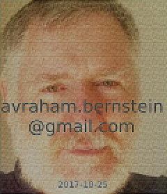

Secure[^1] watermarked photo of the author from 2017: Avraham Bernstein

My profession is a computer scientist and inventor. I have a long and successful track record inventing and implementing [algorithms](https://en.wikipedia.org/wiki/Algorithm) in a wide range of application domains such as automotive, pay TV, [VLSI](https://en.wikipedia.org/wiki/Very_Large_Scale_Integration) [CPU](https://en.wikipedia.org/wiki/Central_processing_unit) design, shop floor production control, [bioinformatics](https://en.wikipedia.org/wiki/Bioinformatics), accessibility, and telecommunications. I am hired to solve challenging and interesting problems that have greatly benefited my employers and clients. A common technique that I use is developing [DSLs](https://en.wikipedia.org/wiki/Domain-specific_language) (Domain-Specific Language) and their associated [compilers](https://en.wikipedia.org/wiki/Compiler). And I have unique expertise in the sub-speciality of cybersecurity related to anti-[reverse engineering](https://en.wikipedia.org/wiki/Reverse_engineering), aka [obfuscation](https://www2.cs.arizona.edu/~collberg/Teaching/553/2011/Resources/obfuscation.pdf).

I invent software [algorithms](https://en.wikipedia.org/wiki/Algorithm). Recently I was granted patents in the field of fast embedded software updates for the automotive industry. Typically for all my inventions I must implement a working POC (Proof Of Concept), and often I also implement a MVP (Minimum Viable Product). I am a hands-on technology expert who comfortably swims from the highest conceptual level down to the lowest level of bits and bytes.

For many projects I invent a [DSL](https://en.wikipedia.org/wiki/Domain-specific_language) (Domain-Specific Language), that [compiles](https://en.wikipedia.org/wiki/Compiler) into working software. Where feasible I design the [DSLs](https://en.wikipedia.org/wiki/Domain-specific_language) to be [declarative](https://stackoverflow.com/questions/1619834/what-is-the-difference-between-declarative-and-procedural-programming-paradigms) - as opposed to procedural. [DSLs](https://en.wikipedia.org/wiki/Domain-specific_language) greatly simplify the problem space especially for domain experts who are not software professionals. And [DSLs](https://en.wikipedia.org/wiki/Domain-specific_language) greatly help to rigorously specify testable software architectures and specifications.

I am an [expert generalist](https://simplicable.com/new/expert-generalist) and an [autodidact polymath] [^2]. My secret weapon is a subscription to the [O’Reilly Safari](https://www.oreilly.com/library/view/learning-java-4th/9781449372477/pr02s07.html) technical library. I am able to *synthesize* my knowledge. I am often able to apply the skills and knowledge that I acquired in one domain, and successfully apply them to another. To get to this level of expertise so quickly, I have often relied upon domain experts who mentored me. In return, I have mentored many others.

*My ideal career position is to be either a principal engineer or an [algorithm](https://en.wikipedia.org/wiki/Algorithm) designer reporting to either the CTO or the VP R&D.* For a large firm, I aim to be a senior person on the technical ladder as opposed to the management ladder. I prefer working independently, or otherwise managing a small team, where I shine as a mentor. Formerly I had senior management positions, but I prefer to return to the individual contributor path. See this article about the benefits to a firm by having managers who have returned to become [individual contributors](https://swaroopch.com/back-to-ic). (And my formal background in economics and business is an important added value which allows me to engage in [economic thinking](https://www.joelonsoftware.com/2002/06/12/strategy-letter-v/)). Just like Picasso never stopped loving and creatively painting throughout his whole life, I love and thrive on the intellectual challenge of inventing software algorithms - which obviously requires that I be a master software engineer. *Even though I am now in my 60’s, you can see from my recent patents that I am still at the top of my game. I have come to the conclusion that I want to continue working only on what I enjoy doing best.*

I attended university in Toronto Canada where I received a Master’s degree in economics and applied mathematics. My thesis was the economically efficient design of a [hydroelectric dam](https://en.wikipedia.org/wiki/Hydroelectricity) using computer simulation of water flow. At the age of 14, my first major programming project was to program a *perfect* game of 3D X’s and O’s (aka [Qubic](https://img0.etsystatic.com/053/1/11127679/il_570xN.771759904_fqi9.jpg)) played on a stack of four transparent 4x4 boards. I wrote the program in Fortran on a [mini-computer](https://en.wikipedia.org/wiki/IBM_1130) that had just 64 **KB** RAM including the space required for the O/S.

The following are many of the application domains in which I have worked:

NAVIGATION HINT: In order to see more details, press the right arrowhead character (▶). But once an arrowhead section, i.e. an HTML details section, is open, external links that you jump to from inside the section should be opened in a new browser tab, i.e. typically using a right mouse button click, otherwise the details section will close when you return from the external link.

1. **automotive: 2018-22:** [Aurora Labs](https://www.auroralabs.com), [Argus](https://argus-sec.com/)

   **(a) I worked on greatly increasing the efficiency of vehicle software updates. My IP (Intellectual Property) enabled my employer to set up a business unit in this field. (b) I invented and patented algorithms in the fields of [delta compression](https://en.wikipedia.org/wiki/Delta_encoding) and assembly hot patching. (c) I developed *legal and safe* workarounds to the fundamental [Misra C](https://en.wikipedia.org/wiki/MISRA_C) restrictions on the use of dynamic memory allocations and variable length structures. These restrictions forced most software architects and programmers into abandoning many of the software advances made in the past 20 years.**
   1. Most vehicles have 50-100 ECUs (i.e. small microprocessors) inside them. The ECUs are used to to control the engine, brakes, climate control, etc. These ECUs are connected to the main computer in the vehicle often via a very slow legacy [CAN bus](https://en.wikipedia.org/wiki/CAN_bus) with an effective payload bandwidth of 128-512 kilo *bits* per second. It can literally take 2 or more hours to update all of the software on these ECUs even though the updates are [zip compressed](https://openzipfile.net/compression-algorithms.html). Typically during the update process, the vehicle is immobilized.
   2. Historically for financial reasons, because the extra FLASH could add $25-50 to the cost of each vehicle, most manufacturers do not provide sufficient spare FLASH space on their ECUs to handle double banked A/B updates, where A is the original version and B is the new version. Therefore the update *cannot* take place in the background, and the vehicle is inoperable during the update process, because B will overwrite A. Often the update must take place at a vehicle service center, so someone, whether or not the owner or the manufacturer, must pay for the time that the vehicle sits in the service bay - easily $50-75 per hour.
   3. The [delta compression](https://en.wikipedia.org/wiki/Delta_encoding) algorithm is fundamentally different than the more well known [zip compression](https://openzipfile.net/compression-algorithms.html) algorithm. [Zip compression](https://openzipfile.net/compression-algorithms.html) searches for common strings, or byte sequences, in a file. It builds a dictionary of the common strings at the beginning of the encrypted file. The body of the encrypted file substitutes abbreviations for the dictionary entries, wherever the entry is encountered in the original file. Simplistically, assuming that the dictionary entries are at least 4 bytes long, but can abbreviated with just 2 bytes, then we can understand the net gain from using [zip compression](https://openzipfile.net/compression-algorithms.html). Note that the zip algorithm requires only sufficient space in FLASH to store B, i.e. the updated file.
   4. However in the case of [delta encoding](https://en.wikipedia.org/wiki/Delta_encoding), the algorithm searches for common strings in 2 different versions of a similar file, say version 1.0 and version 1.1. It may be the case that only a few bytes differ. The patch file contains the location and the values of the differences, i.e. the deltas. [Zip compression](https://openzipfile.net/compression-algorithms.html) of a binary executable typically can compress the original file by a factor of 2.5-3.0 times. But in the case of closely related versions of a similar file, the deltas can be over 10 times smaller.
   5. But the industry standard [delta compression](https://en.wikipedia.org/wiki/Delta_encoding) algorithm, [bsdiff](https://www.daemonology.net/bsdiff/), requires enough space in FLASH to hold *both* the original A file, and at least enough space for a temporary copy of B, i.e. the updated file. But in the typically RAM and FLASH restricted environments found in vehicles, there is not enough memory to store a copy of both A and B, therefore the standard [bsdiff](https://www.daemonology.net/bsdiff/) algorithm is fundamentally infeasible. *My invention was to tweak the algorithm to get around this limitation with nearly the same level of compression efficiency.* Due to potential patent filing issues, I cannot (yet) describe here how I accomplished this feat. Note that I was in correspondence with the inventor, [Colin Percival](https://www.daemonology.net/bsdiff/), of the FOSS (Free Open Source Software) [bsdiff](https://www.daemonology.net/bsdiff/) algorithm.
   6. I also experimented with Google’s FOSS [Courgette](https://www.chromium.org/developers/design-documents/software-updates-courgette) [delta compression](https://en.wikipedia.org/wiki/Delta_encoding) algorithm. Unlike [bsdiff](https://www.daemonology.net/bsdiff/) compression which is instruction set agnostic, [Courgette](https://www.chromium.org/developers/design-documents/software-updates-courgette) is based upon (a) having access to assembly source code with full symbol information, and (b) the target device must have an assembler and linker. [Courgette](https://www.chromium.org/developers/design-documents/software-updates-courgette) usually generates updates that are much more compact than pure [bsdiff](https://www.daemonology.net/bsdiff/). Google claims up to 7 times smaller. Google successfully uses [Courgette](https://www.chromium.org/developers/design-documents/software-updates-courgette) to push updates for their [Chromium](https://www.chromium.org/) and Android projects where there is sufficient room on the target to host a (mini) assembler and linker.
      - *Prima facie* having an assembler and linker on a target ECU device would be impossible due to the severe RAM and FLASH size constraints. However I invented a way to implement a table driven [Courgette](https://www.chromium.org/developers/design-documents/software-updates-courgette)-like algorithm on a small ECU without the need for an assembler or linker, as long as a symbol table was available.
   7. I invented and patented an algorithm for assembly hot patching [ELF](https://en.wikipedia.org/wiki/Executable_and_Linkable_Format) binary files (i.e. without source code, but with the help of a symbol table). The algorithm was easily ported to a number of different [CPU](https://en.wikipedia.org/wiki/Central_processing_unit) architectures.
      - Most of the implementation effort involved patching [ELF](https://en.wikipedia.org/wiki/Executable_and_Linkable_Format) files, parsing linker map files, and generating (esoteric) [gcc linker scripts](https://ftp.gnu.org/old-gnu/Manuals/ld-2.9.1/html_chapter/ld_toc.html#TOC6).
   8. Since Dec 2021, I have been working in the CTO office of [Aurora Labs](https://www.auroralabs.com), where my current focus is to improve their (patented) unique C source code delta compression algorithm. The [Aurora Labs](https://www.auroralabs.com) algorithm compresses more efficiently than the algorithms of the their competitors in the automotive industry who rely upon delta compression of binaries; and it has another unique advantage of supporting rollbacks. I am building a POC that is expected to be much less complex, faster and consumes much less workstation RAM than their existing algorithm. It will also be provably invertible which is very important for QA and safety standards approval.
      1. I am building the POC with the FOSS [SrcML](https://www.srcml.org/) package along with the Python FOSS [Beautiful Soup](https://beautiful-soup-4.readthedocs.io/en/latest/) library. [SrcML](https://www.srcml.org/) can *bidirectionally* convert C source code to an XML abstract syntax tree ([AST](https://en.wikipedia.org/wiki/Abstract_syntax_tree)). [Beautiful Soup](https://beautiful-soup-4.readthedocs.io/en/latest/) is a superb library that can both query and *modify* an XML document. IMPO [Beautiful Soup](https://beautiful-soup-4.readthedocs.io/en/latest/) is much more powerful and elegant than the more commonly used [XQuery](https://www.w3schools.com/xml/xquery_intro.asp) package. By choosing to use [SrcML](https://www.srcml.org/), it completely obviated the need for the relatively complex and time-consuming task of designing a full-fledged C [compiler](https://en.wikipedia.org/wiki/Compiler) - even with the help of an off-the-shelf [drop-in grammar](https://github.com/antlr/grammars-v4). (Under the hood [SrcML](https://www.srcml.org/) is implemented with the [ANTLR](https://www.antlr.org/) compiler framework). I am very pleased with the results of this source code refactoring project. I would highly recommend these tools to my professional colleagues involved in similar projects.
      2. In order to build a single common [jump table](https://stackoverflow.com/questions/9932212/jump-table-examples-in-c) for both static and global functions, I generated unique global alias [gcc function attribute](https://gcc.gnu.org/onlinedocs/gcc/Common-Function-Attributes.html) for all static functions.
   9. My secondary task was [Misra C](https://en.wikipedia.org/wiki/MISRA_C) enforcer, consultant, and hacker.
      1. [Misra C](https://en.wikipedia.org/wiki/MISRA_C) software conformance is *legally* mandated in the vehicle and medical industries. If there are serious accidents resulting from using non-conforming products then *punitive* damages can bankrupt firms, and possibly lead to criminal charges against directors and senior management.
      2. I selected the [Misra C](https://en.wikipedia.org/wiki/MISRA_C) validation compiler used by my employer.
      3. I developed techniques that in many instances could *legally and safely* work around the fundamental [Misra C](https://en.wikipedia.org/wiki/MISRA_C) restrictions, namely on the use of dynamic memory allocations and variable sized structures that forced most developers to disregard modern programming practices in use since 2000. I developed a showcase *read-only* configuration application many times larger than RAM that could be dynamically downloaded into a predefined FLASH address. This showcase application incorporated 2 experimental software design preprocessing techniques that proved to be extremely successful.
      4. Instead of building a parser for the user input (which would have greatly increased the code footprint along with the attack surface), I invented a [DSL](https://en.wikipedia.org/wiki/Domain-specific_language) configuration language that tweaked the C language [designated initializer syntax](https://stackoverflow.com/questions/47202557/what-is-a-designated-initializer-in-c). I implemented the [DSL](https://en.wikipedia.org/wiki/Domain-specific_language) with a simple [sed](https://en.wikipedia.org/wiki/Sed) script. It allowed users to specify complex *constant* numeric expressions that were *statically resolved at compile time*. User configuration scripts are statically compiled, but dynamically loadable, instead of being dynamically parsed.
      5. And instead of forcing string values to have a fixed maximum length (that potentially wastes huge amounts of memory, but would normally be required by [Misra C](https://en.wikipedia.org/wiki/MISRA_C) restrictions) I was able to support variable length string values by using the Python [pyexpander](https://pyexpander.sourceforge.io/) macro preprocessor combined with a string template mechanism based upon Python’s relatively new [f-string](https://realpython.com/python-f-strings/) syntax. The alternative would have been to use the more complex, but admittedly ubiquitous industry standard, [Jinja2](https://jinja2docs.readthedocs.io/en/stable/) preprocessor.
      6. Again I would highly recommend the use of [pyexpander](https://pyexpander.sourceforge.io/) as a macro preprocessing language especially due to the advent of the new [f-string](https://realpython.com/python-f-strings/) syntax. Except for a very small number of strategic syntactic additions, [pyexpander](https://pyexpander.sourceforge.io/) relies upon 100% standard Python syntax. Therefore it is much less difficult to learn and to use than [Jinja2](https://jinja2docs.readthedocs.io/en/stable/) which shines only when an elaborate [object oriented](https://en.wikipedia.org/wiki/Object-oriented_programming) hierarchy of templates is necessary.
      7. And I modified the small RAM footprint FOSS [xz embedded](https://tukaani.org/xz/embedded.html) compression algorithm, so that it would *not* use dynamic memory allocations which are illegal in [MISRA C](https://en.wikipedia.org/wiki/MISRA_C) environments.
2. **Internet and satellite pay-TV: 2004-17:** [Viaccess-Orca/Orange](https://www.viaccess-orca.com/), [NDS](https://en.wikipedia.org/wiki/Synamedia)

   **(a) cybersecurity research (b) anti-[reverse engineering](https://en.wikipedia.org/wiki/Reverse_engineering), aka [obfuscation](https://www2.cs.arizona.edu/~collberg/Teaching/553/2011/Resources/obfuscation.pdf) (c) lightweight cryptography, where I am continuing to do my own independent research until today for the purpose of possibly building my own [obfuscating compiler](https://github.com/JonathanSalwan/Tigress_protection)**
   1. I developed anti-[reverse engineering](https://en.wikipedia.org/wiki/Reverse_engineering) techniques in order to protect the proprietary multimedia content streamed into user playback devices, e.g. PCs, smartphones, set top boxes. A [DRM](https://en.wikipedia.org/wiki/Digital_rights_management) (Digital Rights Management) scheme was used to protect multimedia content. The [DRM](https://en.wikipedia.org/wiki/Digital_rights_management) protected content contains many keys, which if discovered would allow the content to be pirated, or worse even the content servers to be pirated.
   2. Soon after Intel and AMD incorporated [hardware virtualization](https://www.cse.msu.edu/~cse820/lectures/hardwareVirtualization.pdf) support into their X86-64 instruction set, desktop virtualization applications (e.g. [VMware Workstation](https://en.wikipedia.org/wiki/VMware_Workstation), VirtualBox, and [libVirt](https://en.wikipedia.org/wiki/Libvirt)) became popular. I discovered a trivial roll back hack how to use them to foil [DRM](https://en.wikipedia.org/wiki/Digital_rights_management) schemes that were date and playback count restricted. And I discovered how to hack the X86-64 [RDTSC](https://www.felixcloutier.com/x86/rdtsc) instruction that *the host machine [hypervisor](https://en.wikipedia.org/wiki/Hypervisor) passes to the virtual machine*, where the [RDTSC](https://www.felixcloutier.com/x86/rdtsc) instruction returns the 64-bit cumulative number of instruction clock cycles since boot. Many [PRNGs](https://en.wikipedia.org/wiki/Pseudorandom_number_generator) used this instruction as their *exclusive* source of entropy, aka randomness. Therefore [DRM](https://en.wikipedia.org/wiki/Digital_rights_management) client software could be hacked across many pirate clients so that they all responded with the *identical* pseudo-random nonce (i.e. a number used only once), thus allowing the same session key to be shared by the pirate clients, thus allowing all the pirate clients to share a single subscriber’s credentials for viewing the same movie streamed from the server. Even though the more modern (since 2014) [RDRAND](https://www.felixcloutier.com/x86/rdrand) instruction provides much better entropy, it can still be similarly hacked in the [hypervisor](https://en.wikipedia.org/wiki/Hypervisor). Since the hack is done inside the host [hypervisor](https://en.wikipedia.org/wiki/Hypervisor), the [DRM](https://en.wikipedia.org/wiki/Digital_rights_management) application running in the virtual machine has no evidence that it has been tampered.
      - Prohibiting playback inside virtual machines is a waste of time. Use of virtual machines on PCs is ubiquitous. They are also becoming more popular on smartphones. Therefore a possible defense mechanism would be for the server to flag the anomaly that multiple connection requests by a single subscriber for the same content are emanating from multiple geographically diverse IP addresses on the same day.
   3. I was an expert user of C/C++ [obfuscating compilers](https://github.com/JonathanSalwan/Tigress_protection), especially the [Intertrust Whitecryption](https://piracymonitor.org/intertrust-divests-whitecyption-to-zimperium/) tool suite. I acted as their beta tester. I had a close professional relationship with their lead developer because I had already been involved in the specification of similar product based upon identical [LLVM](https://llvm.org/) infrastructure.
      - Based upon the concepts found in [Collberg’s](https://www2.cs.arizona.edu/~collberg/Teaching/553/2011/Resources/obfuscation.pdf) book [Surreptitious Software](https://www.amazon.com/Surreptitious-Software-Obfuscation-Watermarking-Tamperproofing/dp/0321549252), I used the [Jinja2](https://jinja2docs.readthedocs.io/en/stable/) macro preprocessor and template engine to inject small obfuscations into the source code not handled by the Intertrust compiler. See the trivial example immediately below to generate a fast out-of-order loop where the body of the loop is not contingent upon the order of loop traversal (as long as all indices are eventually covered).

      ```c
      // original loop

      for (int i = 0; i < N; ++i) {
          a[i] = b[i] + c[i];
      }

      // transformed obfuscated loop

      // 0 < I_INIT < N
      // 1 < N_COPRIME < (N-1)
      // gcd(N,N_COPRIME) = 1

      for (int i = I_INIT; i < N; i += N_COPRIME) {
          if (i >= N) i -= N;
          a[i] = b[i] + c[i];
      }
      ```

   4. I invented a technique for generating a *usable* Linux [DSO](https://www.webopedia.com/definitions/dynamic-shared-object/) (Dynamic Shared Object, aka `.so`) file that *formally exports no symbols* which makes it quite challenging to statically reverse engineer. In fact the the symbol table was a lightweight encrypted [jump table](https://stackoverflow.com/questions/9932212/jump-table-examples-in-c). Each entry was encrypted using the lightweight encryption wrapper algorithm described immediately below. The table was exported using a hidden asynchronous pipe. The `.h` file associated with the table, contained macros that looked just like regular C function declarations but were in fact implemented as [jump table](https://stackoverflow.com/questions/9932212/jump-table-examples-in-c) invocations. When a [DSO](https://www.webopedia.com/definitions/dynamic-shared-object/) is defined with a function with the constructor [gcc function attribute](https://gcc.gnu.org/onlinedocs/gcc/Common-Function-Attributes.html), the constructor function is automatically invoked before the DSO finishes loading via the system [dlopen()](https://linux.die.net/man/3/dlopen) call.
      - I used a similar technique to lightweight cryptographically wrap all system calls. The technique was able to stop static reverse engineering, and it was even able to blind the state of the art [IDA Hexrays](https://hex-rays.com/IDA-pro/) reverse engineering debugger.
   5. I invented many lightweight cryptographic algorithms to improve [obfuscation](https://www2.cs.arizona.edu/~collberg/Teaching/553/2011/Resources/obfuscation.pdf). The algorithms are also very useful for [IOT](https://en.wikipedia.org/wiki/Internet_of_things) devices. Here are some of the algorithms:
      1. I invented a lightweight cryptographic wrapper function that can quickly and efficiently convert a 32-bit x32 into a pseudo-random 64-bit y64, or convert a 64-bit x64 into a pseudo-random y128. The functions are small enough and fast enough that they can be implemented as [inline functions](https://en.wikipedia.org/wiki/Inline_function). They are especially useful to confuse an attacker who is observing the calling stack. Functions that are regularly called with the same real parameters, will always have different obfuscated parameters - even when the key remains constant, as long as the rnd argument is updated on each call. Note that with minor restrictions this scheme can be used to implement [homomorphic encryption](https://en.wikipedia.org/wiki/Homomorphic_encryption).

      ```c
      #include <stdint.h>

      #ifdef __cplusplus
      #define CC_INLINE       inline
      #else
      #define CC_INLINE       static inline
      #endif

      #ifdef __GNUC__
      #define GCC_ATTRIB(...) __attribute__((__VA_ARGS__))
      #else
      #define GCC_ATTRIB(...)
      #endif

      GCC_ATTRIB(const) CC_INLINE
      uint64_t ayb_wrap32(
          uint64_t key, uint32_t x, uint32_t rnd
      ) {
        const uint64_t z = (uint64_t)(x ^ rnd) |
                              (uint64_t)rnd << 32;
        const uint64_t y = z ^ key;
        return y;
      }

      GCC_ATTRIB(const) CC_INLINE
      uint32_t ayb_unwrap32(uint64_t key, uint64_t y)
      {
        // very important to note that unwrap can be
        // accomplished without any knowledge of rnd

        const uint64_t z = key ^ y;
        const uint32_t rnd = z >> 32;
        const uint32_t x = rnd ^ (uint32_t)z;
        return x;
      }
      ```

      2. I tweaked the extremely fast, but cryptographically *extremely weak*, Adler-32 checksum algorithm in order to make it faster and cryptographically stronger than [CRCs](https://en.wikipedia.org/wiki/Cyclic_redundancy_check).

      ```c
      #include <stdint.h>
      #include <assert.h>

      #ifdef __cplusplus
      #define CC_INLINE       inline
      #else
      #define CC_INLINE       static inline
      #endif

      #ifdef __GNUC__
      #define GCC_ATTRIB(...) __attribute__((__VA_ARGS__))
      #else
      #define GCC_ATTRIB(...)
      #endif

      GCC_ATTRIB(pure,nonnull)
      uint32_t adler32_core(
          const uint8_t *restrict data, int32_t n
      ) {
          // 1. The *core concept* of Adler-32 (derived from
          // Fletcher) is that the checksum is the weighted
          // sum of all the bytes in the data stream, where
          // the weight is the byte's position in the stream,
          // i.e.
          //   sum = 1*data[0] + 2*data[1] + 3*data[2] + ... + n*data[n-1]
          //
          // 2. Even though Alder-32 is *extremely fast* to
          // compute, and is much stronger than the older LRC
          // algorithm (i.e. which simply xors all the bytes
          // in the stream) which among other deficiencies is
          // not byte order dependent, Adler-32 is extremely
          // *cryptographically weak* because for small n, the
          // sum will be much less than 2^32, therefore it
          // will not "spread" itself over the full bit range
          // of sum.
          //
          // 3. Adler-32 is easy to "game", i.e. to generate
          // "collisions". For example when i < j < k
          //      sum = ... + data[i-1]*i + ... + data[j-1]*j + ...
          // or   sum = ... + data[i-1]*i + ... + data[j-1]*j + ... + data[k-1]*k + ...
          // It is not difficult to game/modify the data in
          // order to generate the same sum, namely
          //      sum = ... + data_prime[i-1]*i + data_prime[j-1]*j + ...
          //      etc.

          uint32_t sum = 0;

          for (int32_t i = 0; i < n; ++i) {
              sum += (uint32_t)data[i] * (uint32_t)(i+1);
          }

          return sum;
      }

      GCC_ATTRIB(pure,nonnull)
      uint32_t ayb_checksum32_interim(
          const uint8_t *restrict data, int32_t n, int32_t k
      ) {
          // Based upon the assumption that the expected
          // value of each each byte in the data stream is
          // 128, 'k' should be designed so that the expected
          // return value should be `2^32 - 1` in order to
          // provide the best possible "spread".
          // Therefore in many cases, especially with
          // relatively short messages, changing the length
          // of the input data, by even a single byte, has
          // a major effect on the checksum.
          // Compare this to the original Adler/Fletcher
          // algorithm, where adding a zero byte to the end
          // of the message would not change the checksum.
          // TBD: `2^33 - 1` may provide a stronger checksum.

          uint32_t lrc = 0;
          uint32_t sum = 0;

          for (int32_t i = 0; i < n; ++i) {
              lrc ^= (uint32_t)data[i];
              sum += lrc * (i+1);
          }

          if ((k & 1) == 0) {
              ++k; // force k to be odd
          }

          return sum*k;
      }

      GCC_ATTRIB(const)
      CC_INLINE int32_t ayb_checksum32_calc_mult(int32_t n)
      {
          // recall geometric sum of 1 + 2 + 3 + ... + n = n*(n+1)/2
          // ==> 128*(k + 2*k + 3*k + ... + n*k) = 2^32 - 1
          // ==> 128*k*n*(n+1)/2 = 2^32 - 1
          // ==> k*n*(n+1) ~= 2^26
          // ==> k ~= (2^26)/(n * (n+1))
          // ==> max n < 2^13, otherwise k is zero

          assert(n > 0 && n < 8192); // 2^13 = 8192

          int32_t k = (1L << 26)/(n * (n+1));

          if ((k & 1) == 0) {
              ++k; // force odd
          }

          return k;
      }

      GCC_ATTRIB(pure,nonnull)
      uint32_t ayb_checksum32(
          const uint8_t *restrict data, int32_t n
      ) {
          // calc_mult() contains asserts so it should be the
          // first statement in this function

          const uint32_t k = ayb_checksum32_calc_mult(n);

          // Under real conditions, secret should be non-zero.
          // The secret byte is used to initialize the lrc.
          // This technique increases the difficulty of gaming
          // the checksum by a factor of 256.

          const uint8_t SHARED_AYB_CHECKSUM32_SECRET8 = 0;

          // Even stronger: By starting the message data with
          // a 32-bit time stamp say with a 30 second window,
          // or better by starting with a 32-bit OATH OTP
          // token, greatly limits the degrees of freedom to
          // game the checksum, and of course restricts the
          // use of message replay attacks.

          uint32_t lrc = SHARED_AYB_CHECKSUM32_SECRET8;
          uint32_t sum = 0;

          for (int32_t i = 0; i < n; ++i) {
              // Use of lrc makes the checksum much more
              // difficult to "game" compared to the original
              // Adler/Fletcher algorithm.

              lrc ^= (uint32_t)data[i];
              sum += lrc * (i+1);
          }

          return sum * k;
      }

      GCC_ATTRIB(pure,nonnull)
      uint64_t ayb_checksum64(
          const uint8_t *restrict data, int32_t n
          // max n < 2^29 bytes
      );

      GCC_ATTRIB(pure,nonnull)
      uint64_t ayb_checksuml64(
          const uint32_t *restrict data, int32_t n
          // max n < 2^13 dwords (= 2^15 bytes),
          // and in this version the lrc initialization secret
          // can be 32-bits
      );
      ```

      3. I invented high quality, tiny footprint, and extremely fast [PRNGs](https://en.wikipedia.org/wiki/Pseudorandom_number_generator) (Pseudorandom Number Generators). I validated the [PRNGs](https://en.wikipedia.org/wiki/Pseudorandom_number_generator) with the gold standard [PractRand](http://pracrand.sourceforge.net/) utility. Use of [PRNGs](https://en.wikipedia.org/wiki/Pseudorandom_number_generator) is an important [obfuscation](https://www2.cs.arizona.edu/~collberg/Teaching/553/2011/Resources/obfuscation.pdf) tactic. Each module was assigned its own tiny [PRNG](https://en.wikipedia.org/wiki/Pseudorandom_number_generator), implemented as a C [inline function](https://en.wikipedia.org/wiki/Inline_function), with its own unique random IV (Initialization Vector). This avoids having a single global [PRNG](https://en.wikipedia.org/wiki/Pseudorandom_number_generator) function that is much more easily attacked.
      4. I tweaked the lightweight XXTEA cipher in order to greatly improve its cryptographic strength.
      5. I invented an obfuscated FORTH-like compiler that could dynamically load obfuscated applications into pay-TV set top boxes.
      6. **My most significant crytographic algorithm invention is a UHW (*Uniformly* distributed Hamming Weight)** implemented with DFTs ([Digital Fourier Transformations](https://en.wikipedia.org/wiki/Discrete_Fourier_transform)). A standard HW (Hamming Weight) is the sum of the 1 bits in a binary number. Therefore the range of a HW value is from zero to the number of bits in the number, e.g. typically 32 or 64 depending upon the [CPU](https://en.wikipedia.org/wiki/Central_processing_unit) architecture. The range of a UHW is the same. Standard HWs are non-linear functions, *but they are not cryptographically useful/interesting on account of their underlying [binomial distribution](https://en.wikipedia.org/wiki/Binomial_distribution).* Rotating or permuting the bits in a number according to its HW does not change the HW, therefore the operation is invertible. But a UHW is also non-linear. It is also invariant with respect to bit rotation and permutation, and therefore is invertible *as long as the rotation/permutation uses groups the size of 1/4 of the bits in the underlying value, e.g. 32-bit and 64-bit values.* Cryptographic operations based upon UHWs are much stronger than the DDRs ([Data Dependent Rotations](https://nullprogram.com/blog/2018/02/07/)) permutations made famous by Rivest in his RC5 cipher. For example in RC5 the low 5 bits of the preceding 32-bit value is used to rotate the subsequent 32-bit value. But by using UHWs, the UHW of the preceding 64-bit value could be used to rotate the subsequent 64-bit value. The UHW has many properties similar to standard HWs. I will publish a paper on the algorithm in the near future, including an empirical proof that the distribution is uniform (but with some minor perturbations). Here is the source code of the core algorithm:

      ```c
      #include <stdint.h>

      #ifdef __cplusplus
      #define CC_INLINE       inline
      #else
      #define CC_INLINE       static inline
      #endif

      #ifdef __GNUC__
      #define GCC_ATTRIB(...) __attribute__((__VA_ARGS__))
      #else
      #define GCC_ATTRIB(...)
      #endif

      GCC_ATTRIB(const)
      int ayb_uhw_depth_32(uint32_t x, const int depth)
      {
          #undef BIT_WIDTH
          #define BIT_WIDTH (sizeof(x)*CHAR_BIT)

          assert(depth > 0 && depth <= BIT_WIDTH/2 && IS_POW2(depth));

          // The fundamental idea of the algorithm is to successively
          // divide x into 1-bit, 2-bit, 4-bit, ..., and depth-bit
          // groups where depth is a power of 2, and the max value of
          // depth <= half of the bits in x.

          // When the value of a bit group is greater than half of its
          // maximum value then the group sum, i.e. sum[i] is
          // incremented by 1.
          // The total sum = sum[0]*1 + sum[1]*2 + sum[2]*4 ...

          // The "secret sauce" is: uhw = sum % (BIT_WIDTH + 1)

          // Clearly rotating the bits in x (or permuting it) in groups
          // of depth bits does not change the UHW.

          int sums[LOG2(BIT_WIDTH)] = { popcount(x) };

          int i = 0;
          int shift = 2;
          typeof(x) mask = (1 << shift) - 1;

          for (; shift <= depth; shift <<= 1, mask = (1 << shift) - 1, ++i) {
              for (typeof(x) y = x; y; y >>= shift) {
                  sums[i+1] += (y & mask) > (mask/2);
              }
          }

          int sum = sums[0];

          for (; i > 0; --i) {
              sum += sums[i] << i;
          }

          const int uhw = sum % (BIT_WIDTH + 1);
          // uhw is in the range [0,sizeof(x)*BIT_WIDTH]
          return uhw;
      }

      GCC_ATTRIB(const) CC_INLINE
      int ayb_uhw32(uint32_t x)
      {
          // most efficient depth (in bits) is sizeof(x)*2,
          // i.e. 1/4 of the bit width of x

          return ayb_uhw_depth_32(x, sizeof(x)*2);
      }
      ```

   6. @[Viaccess-Orca/Orange](https://www.viaccess-orca.com/): For many years the movie studios would not allow their [DRM](https://en.wikipedia.org/wiki/Digital_rights_management) protected content to be played on rooted Android devices because they are much easier to debug. Eventually the studios gave up on this demand because such devices were becoming so common that they would lose too many subscribers. But during the years that they were concerned, I developed algorithms to detect rooting. Rooting was a cat and mouse game. The hackers were always discovering new techniques which the OEMs were always trying to block. Declaring a device to be rooted, and automatically revoking credentials, would cause subscribers to howl especially if the detection algorithm were wrong, aka returned a false positive. Worse if thousands of subscriber devices were wrongly declared to be rooted, then the customer service representatives would be bombarded with hostile subscribers, and the negative publicity would be terrible. Therefore it was always prudent to prefer false negatives, i.e. to allow a suspicious device to play content unless it was 200% provable that the device was in fact rooted. My algorithm used a [fuzzy logic](https://en.wikipedia.org/wiki/Fuzzy_logic) scoring system. It very rarely returned false positives, and when it did happen, it was only for a few individual subscribers.
      - When we were forced to abandon root detection on the device, I designed a better protection scheme, this time on the server side, in order to detect *anomalous* behavior. For example, was a subscriber viewing 100+ hours a week (out of 168 hours) of movies? or was his account being activated from many widely separate geographic locations often around the same time of day?
   7. @[NDS](https://en.wikipedia.org/wiki/Synamedia): I was involved in joining hacker smartcard sharing groups that could share credentials in real time on legacy set top boxes. It was possible to detect which cards were being shared, and to disable them live. Similarly I joined hacking groups that would live stream sports broacasts to geoblocked locations, i.e. with 100 km of the stadium. In 2006, the Chinese were notorious for rebroadcasting FIFA Mondial football games around the world, thus reducing the license fees of those companies who owned the broadcast rights. Ironically I was placed in charge of technically protecting the 2008 Beijing Olympic game broadcast from being broadcast outside of China at the behest of the Chinese government TV company CCTV because not preventing these pirate broadcasts would endanger their host country right to broadcast the games internally for free.
      - The Chinese correctly assumed that the pirated feeds would start off from local Chinese viewers looking to make a handsome profit by illegally exporting their local feed, just like they rebroadcast the football games 2 years earlier. CCTV did not want Microsoft to have anything to do with the protection scheme, because at the time nearly every single private PC was using a pirated [Windows XP](https://en.wikipedia.org/wiki/Windows_XP) license, and because CCTV itself was using tens of thousands unlicensed Microsoft servers to broadcast the feed throughout their country. I came up with a very good technical solution. My solution would require that every single PC in China that received the local broadcast would have to install an [NDS](https://en.wikipedia.org/wiki/Synamedia) application. The price would be $0.25 per PC which would have amounted to over $100M in profits. I told the Chinese there were a few geographical regions in China that I could not protect. Because part of my protection scheme relied upon speed of light timing precision of pings, I could not protect the hinterlands that used satellite transmissions, or in the populous Shenzhen region that borders Hong Kong. And I even told them that some of my findings were based upon my analysis of the Great Firewall Of China (GFOC) which at that time the government refused to admit even existed. The Chinese appreciated my brutally honest proposal. NDS was on the threshold of winning the contract. But Microsoft came back with a last minute counter offer - for absolutely free! Microsoft knew very well why they had been excluded from the bidding. They promised not to sue the Chinese government over the illegal licenses. And since at that time Microsoft was a partner with MS-NBC that owned the Olympic broadcast rights, they also promised not to sue even if the feed were illegally broadcast from China. Therefore [NDS](https://en.wikipedia.org/wiki/Synamedia) lost the contract.
   8. @[NDS](https://en.wikipedia.org/wiki/Synamedia): I was the architect and implementor of a hybrid simulator-emulator for *legacy* TV STBs (Set Top Boxes) in order to enable high level debugging of applications implemented for them. Because the still-popular legacy STB had minimal RAM, no high level debugger could be attached to it. Therefore it was being primitively debugged using `printf()` instructions output to a a very slow RS-232 serial port, i.e. 19.2K bits per second. My solution was to simulate the vast majority of the the middleware C language API on a PC. However the hardware specific API functions, e.g. that wrote to the TV display, were redirected to the physical STB from the PC via an [RPC](https://en.wikipedia.org/wiki/Remote_procedure_call) (Remote Procedure Call) mechanism. The final result of the project was that the state of the art [Microsoft Visual Studio debugger](https://en.wikipedia.org/wiki/Microsoft_Visual_Studio#Debugger) could now be used to efficiently debug STB applications - in fact more comfortably than the middleware debugger available on the bigger and more modern STBs because their CPUs were much less powerful than what is available on PCs.
3. **miscellaneous recent compiler projects: 2020-21:** [Qedit](https://qed-it.com/), stealth mode cybersecurity startup

   **(a) patching [x86-64](https://en.wikipedia.org/wiki/X86-64) assembly code (b) [WASM](https://webassembly.org/) (Web Assembly)**
   1. While searching for particular attributes in disassembled X86-64 binary object code (without access to the original high level language source code or symbol table), I automatically patched the assembly code using [trampolines](http://timetobleed.com/hot-patching-inlined-functions-with-x86_64-asm-metaprogramming/) placed inside hidden memory holes inside [ELF](https://en.wikipedia.org/wiki/Executable_and_Linkable_Format) files in order to avoid defining the trampolines in dynamic process memory that would make the [DSO](https://www.webopedia.com/definitions/dynamic-shared-object/) (Linux Dynamic Shared Object, aka `.so`) files effectively unshareable, because each process copy of a [DSO](https://www.webopedia.com/definitions/dynamic-shared-object/) would have process specific jump addresses to their own trampoline instances.
      - In order to restrict my attribute searches to inside the body of a function, I invented accurate heuristics that could detect function definitions/boundaries even without the help of a symbol table, and even where indirect function calls were commonly used. This is known to be an extremely difficult problem in the software industry.
      - I implemented this project in Python, with the help of the excellent FOSS LIEF [ELF](https://en.wikipedia.org/wiki/Executable_and_Linkable_Format) parsing package, and the excellent [Pydis](https://github.com/novogen/pydis) X86-64 disassembly package. [Pydis](https://github.com/novogen/pydis) is a Python port of the outstanding C [Zydis](https://github.com/zyantific/zydis) X86-64 disassembler. Especially helpful is its ability to parse opcode operands, categorize opcodes, and categorize registers. (Note that [no X86-64 disassembler is 100% accurate](https://security.di.unimi.it/homes/gianz/pubs/issta10-nversion.pdf), but [Zydis](https://github.com/zyantific/zydis) is the best-of-breed). Even though [Pydis](https://github.com/novogen/pydis) is not well documented, it follows 90+% the [Zydis](https://github.com/zyantific/zydis) C API. The Python reflective function `dir()` helped me to get around the rough (undocumented) edges. I would highly recommend these tools to my professional colleagues involved in similar projects.
   2. I engaged in [WASM](https://webassembly.org/) (Web Assembly) experiments to speed up javascript apps.
4. **[bioinformatics](https://en.wikipedia.org/wiki/Bioinformatics): 2009:** [Syntezza](https://www.syntezza.com/)

   **invented [PCR](https://en.wikipedia.org/wiki/Polymerase_chain_reactio) algorithms**
   1. The client’s product was a novel *dry* [MRSA](https://www.mayoclinic.org/diseases-conditions/mrsa/symptoms-causes/syc-20375336) detection kit based upon [PCR](https://en.wikipedia.org/wiki/Polymerase_chain_reactio) analysis of patient samples. [MRSA](https://www.mayoclinic.org/diseases-conditions/mrsa/symptoms-causes/syc-20375336) thrives in hospitals where it is the leading cause of iatrogenic deaths. [MRSA](https://www.mayoclinic.org/diseases-conditions/mrsa/symptoms-causes/syc-20375336) is a potentially fatal strain of antibiotic resistant staphylococcus especially for hospital patients who are already immunologically compromised.
   2. When I started the project, their initial accuracy was 50% which is completely unacceptable. Consequently they were on the verge of liquidation. But within 3 months, I raised their detection rate to 95+% (!) which was 10% more accurate than their competitors from the giant pharmaceutical companies. We had a shoot out at the famous [St. Georges](https://www.stgeorges.nhs.uk/) medical school hospital, where my algorithm won!
   3. I improved upon existing classic industry standard [PCR](https://en.wikipedia.org/wiki/Polymerase_chain_reactio) mathematical algorithm that resulted in superior normalization and noise correction on multiple [PCR](https://en.wikipedia.org/wiki/Polymerase_chain_reactio) (laser) channels.
      1. By simply subtracting the negative control data from the patient sample data, on a channel by channel basis, was much simpler and produced far more accurate normalization including correction of systematic noise.
      2. The classic algorithm does not account for the systematic and significant reaction delays on the different channels. Taking into account these delays provided much more accurate estimates.
      3. I was mentored by [Tzachi Bar](https://www.researchgate.net/profile/Tzachi-Bar) who was the inventor of the classic algorithm.
   4. And I invented a completely new class of [PCR](https://en.wikipedia.org/wiki/Polymerase_chain_reactio) algorithm to handle dirty (i.e. high [inhibition](https://en.wikipedia.org/wiki/Polymerase_chain_reaction_inhibitor)) data that the classic algorithm is fundamentally incapable of handling.
   5. Unlike the classic algorithm which is based upon mathematically estimating the inflection point of a sigmoidal (flat S) shaped curve typical of biological assays, formally called the [logistic function](https://en.wikipedia.org/wiki/Logistic_function), instead my new algorithm used AI (Artificial Intelligence) threshold detection techniques.
   6. One of the major problems with the classic algorithm is that it will estimate (via the [Levenberg-Marquardt algorithm](https://en.wikipedia.org/wiki/Levenberg%E2%80%93Marquardt_algorithm)) the 4 (or 5) [logistic function](https://en.wikipedia.org/wiki/Logistic_function) parameters with a very high [correlation coefficient](https://www.ncbi.nlm.nih.gov/pmc/articles/PMC3576830/), e.g. R > 99%, even when the underlying points have absolutely no relation to a sigmoidal shaped curve. I like to say that when trying to estimate a single hump camel, the algorithm will declare success when it encounters a horse with a wart on its back. Note that the kit used an automated algorithm, with no human eye balls monitoring the process. I worked around this problem by prescanning the data with a 5 part piecewise linear regression estimate of its shape. If the piecewise estimate did not match a sigmoidal shape then I knew that the classic algorithm would not work.
   7. *I literally saved the client from bankruptcy because their preliminary chemistry had very high [inhibition](https://en.wikipedia.org/wiki/Polymerase_chain_reaction_inhibitor), and because I discovered and corrected (after the fact) the critical protocol mistake where the hospitals had been incorrectly instructed to place the patient samples and control samples in the wrong test tube slots. I noted this anomaly when I discovered how in many cases pure laboratory colony samples of [MRSA](https://www.mayoclinic.org/diseases-conditions/mrsa/symptoms-causes/syc-20375336) were incorrectly identified.*
   8. *All of this work was done within just 3 months even though I had absolutely no background in biology or biochemistry! My education was jump started via mentoring from a senior microbiologist, along with the inventor of the classic algorithm.*
5. **accessibility: 1988-present:** Cubital (defunct), Virtouch (defunct), and continuing independent research until today

   **invented algorithms and applications for the blind, [dyslexics](https://en.wikipedia.org/wiki/Dyslexia), and quadriplegics**
   1. I developed algorithms for the blind so that they could navigate standard geographic maps specified according to the industry standard [GML](https://en.wikipedia.org/wiki/Geography_Markup_Language) (Geography Markup Language). Similarly they could navigate street maps and public transportation maps.
   2. And I developed algorithms that allowed the blind to learn high school mathematical functional analysis, e.g. to investigate [conic sections](https://encyclopediaofmath.org/wiki/Conic_sections), and intersecting lines, etc.
   3. The above algorithms relied upon (1) the industry standard [SVG](https://en.wikipedia.org/wiki/Scalable_Vector_Graphics) (Scalable Vector Graphics) package found on all modern web browsers, and (2) sound cards found on all PCs and smart phones. Ideally the blind user should navigate with a graphics tablet and stylus (typically available for under $100), or a device with a touch screen. Blind people have accurate hand to mind’s-eye coordination, in the sense that they can easily navigate a graphics tablet, i.e. to the corners, the edges, and to the middle. However a mouse is very difficult for them to use because when moving it beyond the edge of the display, the cursor stops even though the mouse keeps moving. They lack the visual feedback required to detect the mouse cursor position, which is not the case when a graphics tablet is programatically defined to be a rectilinear mapping into the display.
      1. The core sound inventive technique was that there was always background audio feedback at the cursor position. The display was conceptually divided into a grid of 5 (or more depending upon the audio acuity of the user) 12-note (chromatic) octaves in the vertical and horizontal direction. The vertical axis was assigned one instrument, say a piano, while the horizontal axis was assigned a second instrument, say a flute. Therefore the user would always hear a low volume combination of notes at the current cursor position.
      2. Interesting objects on the display would use the same audio cursor technique, but at a higher level of volume. Say one is tracing a circle whose circumference (a few pixels wide) is indicated in white, while the rest of the screen has a black background. When the cursor is over the circumference the volume would be much louder than when over the background.
      3. Similarly when searching for the point where two lines intersect, as the cursor approached the intersection point, the volume would increase.
      4. By defining the screen objects with [SVG](https://en.wikipedia.org/wiki/Scalable_Vector_Graphics), there can be a seamless zoom-in and zoom-out. By default the graphics tablet would be rectilinear mapped to the current window dimensions.
      5. In the case of geographic maps, say a topographical map, to display elevation, the user could redefine the isotherm granularity, e.g. every 10 meters or every 100 meters. And the user could help to define his own color legend, which could be mapped to different instrument combinations.
   4. I invented an algorithm for automatically modifying fonts that makes them much easier for [dyslexics](https://en.wikipedia.org/wiki/Dyslexia) to recognize. It is not effective to simply place a dot at the bottom of each letter like sixes and nines are often differentiated for normal readers because (1) dyslexics typically can flip/reverse letters across the middle vertical axis, and (2) without extending the upper and lower margins bordering each letter, when viewing lines of text *where every lettered is dotted*, it would be extremely difficult to determine whether or not a dot is above or below a letter. Instead my invention is based upon a *similar* principle used for machine vision identification of a [QR code](https://en.wikipedia.org/wiki/QR_code). Namely a [QR code](https://en.wikipedia.org/wiki/QR_code) has 3 relatively large black squares in 3 of the 4 corners, i.e. in the top-left, top-right, and bottom-left, *but not the bottom-right*. Therefore it is trivial for an image processing application to rotate the [QR code](https://en.wikipedia.org/wiki/QR_code) into its canonical position. So now if we automatically widen the left and right margins of a character with an identical amount of padding on each side, and conceptually divide the left margin in half with a vertical line, and place a small dot in the middle of the inner half of the expanded left margin, then the single simple rule for a dyslexic reader, is that there must be a dot in middle of the the inner half of the left margin.

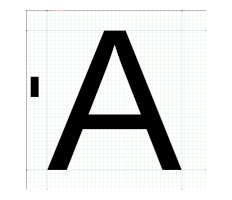

      Dyslexic Font: A

   5. Many years before the era of inexpensive speech recognition software and before the era of LCD computer displays, I co-invented a mechanism for quadriplegics (i.e. having a disability where they cannot use their arms or legs) to type into a computer using a telescopically enhanced [light pen](https://en.wikipedia.org/wiki/Light_pen) as a pointing device (with a range of 80 cm.), and a selector mechanism using a [sip and puff switch](https://www.rehabmart.com/product/sip-and-puff-assistive-technology-switches-32190.html). The light pen was attached to the user’s head via a woman’s plastic hair band. I also invented (but unfortunately never patented) a virtual keyboard that overlaid onto the display. In expert touch type mode, just a single letter popped up on to the display at the current light pen pointer position. Our first subject, Shulamit Gabai, was a school teacher who had become afflicted with polio from a sewage pipe accident in the Israeli town of Or Akiva. As a result she became a quadriplegic. With the help of the device, she could type 30 characters a minute, that enabled her to become an editor for a book publisher.
   6. @Virtouch in my capacity of CTO, I was hired in order to change their initial product focus that was designed to help blind children, into tools that could help blind adults at work. Around the world most government social welfare agencies would gladly subsidize tools for the blind that helped them enter the workforce. I made a funding proposal to the EU innovation ministry in the framework of their FP6 program in order to continue and enhance the products that I described above. I won a *matching* grant of 200K Euro to be administered by the Office of the Israeli Chief Scientist. However the company was on the verge of bankruptcy, on account of their failures in the children’s market. The board of directors refused to invest any more funds into the company regardless of the availability of matching funds. Consequently the company closed shortly afterwards.
   7. *My work in accessibility gives me the most personal satisfaction, but unfortunately it usually provides me with the least financial remuneration.*
6. **online privacy & personal cybersecurity: 2000-present:** [Canary Mission](https://canarymission.org/), and continuing independent research until today
   - Internet hygiene for the masses
7. **transportation vehicle guidance: 2010:** Telequest (defunct)
   - invented algorithms for guiding vehicles through urban traffic (similar to what [Waze](https://www.waze.com/) does)
8. **telecommunications: 1998-2004:** Phasecom-Vyyo (defunct), Jolt (defunct), TMT (defunct), [NDS](https://en.wikipedia.org/wiki/Synamedia)

   **hybrid protocols, operations research, algorithms, QA, [DSL](https://en.wikipedia.org/wiki/Domain-specific_language), communications laboratory architecture**
   1. I invented and implemented a protocol for hybrid devices with a fast downstream channel, and slow upstream channel.
      1. The device was a cable modem that was not technically (or sometimes legally) enabled to support an upstream channel, so telephone dial-up was used for the upstream.
      2. The Korean operator that supplied the cable modem service, also supplied the telephone dial-up service.
      3. Therefore I was able to dynamically reprogram the the site’s edge router *static* [arp table](https://www.auvik.com/franklyit/blog/what-is-an-arp-table/) to redirect downstream traffic from the dial-up to the cable modem.
      4. We applied for a provisional patent, but never finalized the official patent.
   2. I developed a simulator [DSL](https://en.wikipedia.org/wiki/Domain-specific_language) and QA test environment for a satellite handling hundreds of TV channels.
   3. I developed communication laboratory modem speed testing software that used a [steepest descent](https://en.wikipedia.org/wiki/Gradient_descent) algorithm, instead of the industry standard [binary search](https://en.wikipedia.org/wiki/Binary_search_algorithm) algorithm. Typically the [steepest descent](https://en.wikipedia.org/wiki/Gradient_descent) algorithm ran 10x faster.
   4. I was the architect of a communication laboratory that multiplexed a few hundred modems to less than 10 PCs. Normally a single PC could be physically attached to at most 4 modems, but by dynamically reprogramming the routers and smart network switches, the PCs could share modems. This architecture saved tens of thousands of dollars in communications equipment costs and laboratory infrastructure costs.
   5. I developed a FORTH [compiler](https://en.wikipedia.org/wiki/Compiler) that could be used for dynamically loading applications into network devices in order to remotely debug them.
   6. I invented an extremely efficient [arp table](https://www.auvik.com/franklyit/blog/what-is-an-arp-table/) [hash table](https://en.wikipedia.org/wiki/Hash_table) algorithm for an embedded router. No dynamic memory allocations were used. The [hash table](https://en.wikipedia.org/wiki/Hash_table) algorithm was unique because it used a binary mask to find the initial entry, as opposed to the more common modulo or floating point multiplicative technique. And the hash table could be grow without having to move the position of any of the already existing entries.
   7. I implemented an [SNMP](https://en.wikipedia.org/wiki/Simple_Network_Management_Protocol) based NMS (network management system) that could handle thousands of devices. Also I implemented the SNMP agents on the modems.
9. **Mil-spec QA: 1994-95:** [Elop/Elbit](https://elbitsystems.com/about-us-quality-assurance-elbit-systems-electro-optics-elop/), Pitkha (defunct)

   **(a) invented a [DSL](https://en.wikipedia.org/wiki/Domain-specific_language) that was used to implement thousands of mil-spec QA tests for the Israeli manufactured fire control subsystem of the US Army’s [BlackHawk](https://en.wikipedia.org/wiki/Sikorsky_UH-60_Black_Hawk) helicopter**
   1. The client received a 2 meter pile of test requirement documents from the main US contractor.
   2. The fire control system was to be stress tested under a wide range of conditions such as vibration, temperature, humidity, electric voltage and current, etc.
   3. The longest test duration was 72 hours.
   4. The biggest challenge was that the main US contractor was regularly updating the tests.
   5. Originally the client considered writing a custom C program to handle each test separately.
   6. Instead they accepted my suggestion to design a [DSL](https://en.wikipedia.org/wiki/Domain-specific_language) resembling the BASIC programming language which I built using the [compiler](https://en.wikipedia.org/wiki/Compiler) generation tools [lex and yacc](http://dinosaur.compilertools.net/) (at that time the premier tool in the industry, although today, in 2021, they are considered to be long in the tooth). The [DSL](https://en.wikipedia.org/wiki/Domain-specific_language) was used to design typically short scripts that implemented each test. Even though the client’s system engineers were not programmers, they were quickly able to learn to modify tests on their own, and to build their own *ad hoc* tests.
   7. The DSL contained drivers to communicate with the fire control system, along with all of the test equipment.
   8. According to the client’s hard requirement, the test PCs would be running MS-DOS.
   9. The project was very successful.
   10. By the end of the project, [Windows NT](https://en.wikipedia.org/wiki/Windows_NT) was being introduced into the market that would run [TCL](https://en.wikipedia.org/wiki/Tcl) which would have obviated the necessity of building a custom [DSL](https://en.wikipedia.org/wiki/Domain-specific_language). It would have been a better solution, but it arrived too late for this project. For the next 20 years, my first choice for architecting a [DSL](https://en.wikipedia.org/wiki/Domain-specific_language) was to piggy back on [TCL](https://en.wikipedia.org/wiki/Tcl) instead of building a custom compiler.
10. **[VLSI](https://en.wikipedia.org/wiki/Very_Large_Scale_Integration) [CPU](https://en.wikipedia.org/wiki/Central_processing_unit) design: 1991-93 & 1998:** [DSPG](https://www.dspg.com/), Pitkha (defunct), Fourfold (defunct)

    **(a) invented a [DSL](https://en.wikipedia.org/wiki/Domain-specific_language) that could extremely accurately simulate a [DSP](https://en.wikipedia.org/wiki/Digital_signal_processor) [CPU](https://en.wikipedia.org/wiki/Central_processing_unit), along with designing a software development toolchain including C compiler, linker, assembler, and debugger (b) wrote a C compiler for a 128 core stack based [CPU](https://en.wikipedia.org/wiki/Central_processing_unit)**
    1. @[DSPG](https://www.dspg.com/): 1992
       1. Application software developers used these tools to develop working applications 6 months before the final chip was physically available.
       2. The [VLSI](https://en.wikipedia.org/wiki/Very_Large_Scale_Integration) architects used these tools to write assembly code sanity tests that executed 1000x faster than VHDL - but just as accurately.
       3. This early [CPU](https://en.wikipedia.org/wiki/Central_processing_unit) could not automatically resolve pipeline collisions; therefore either the assembler had to warn about them, or to attempt to automatically fix them.
       4. The invention of the [DSL](https://en.wikipedia.org/wiki/Domain-specific_language) was critical to the success of this project, because the [VLSI](https://en.wikipedia.org/wiki/Very_Large_Scale_Integration) architects regularly updated their internal architecture (often a few times per week), especially the implementation of the pipeline. Seemingly minor changes to the pipeline could have major impact on many assembly instructions. It was not feasible to update the assembler manually every time the pipeline changed, but with the help of the [DSL](https://en.wikipedia.org/wiki/Domain-specific_language), the complete toolchain could be rebuilt within 2 hours.
       5. At this time the generic [GNU toolchain](https://en.wikipedia.org/wiki/GNU_toolchain) was not yet mature, therefore the C compiler and linker had to be written from scratch.
    2. @Fourfold: 1998
       1. By this time the [gcc](https://gcc.gnu.org/) compiler framework had matured, but it was not (and still is not) designed to implement a stack machine architecture (with effectively unlimited registers), or a multi-core architecture. It was wise to attempt to leverage the very substantial [gcc](https://gcc.gnu.org/) infrastructure. So I designed a [DSL](https://en.wikipedia.org/wiki/Domain-specific_language) that could transform this unusual architecture into a form that [gcc](https://gcc.gnu.org/) compiler framework could digest.
11. **shop floor production control: 1989-91:** [Iscar](https://www.iscar.com/newarticles.aspx/countryid/1/newarticleid/259), DEC (defunct)

    **invented a [DSL](https://en.wikipedia.org/wiki/Domain-specific_language) that could configure and fully automate a factory that produced thousands of different kinds of cutting blades**
    1. The [DSL](https://en.wikipedia.org/wiki/Domain-specific_language) describes a generic factory.
    2. The underlying [declarative](https://stackoverflow.com/questions/1619834/what-is-the-difference-between-declarative-and-procedural-programming-paradigms) DSL was [object oriented](https://en.wikipedia.org/wiki/Object-oriented_programming) based upon the principles described in the then-pioneering programming languages, i.e. Smalltalk and C++ 1.0. The final result was a working factory that was completely automated. No people were necessary on the shop floor, other than to watch out for and to deal with emergencies. The project was a smashing success.
    3. My co-architect and I collaborated with an industrial engineer for about 4 months while we fleshed out the language. The object kingdom included workstations, stands, pallets, tools, raw materials, final products, recipes, automatic guided vehicles, conveyor belts, production instructions, etc.
    4. Using the language that we created, the industrial engineer helped the factory engineer to completely describe his factory from A-Z. Neither of them had any background in computer programming, nor did they require such skills.
    5. We implemented the software in [Pascal](https://en.wikipedia.org/wiki/Pascal_%28programming_language%29) (due to a hard customer requirement) in combination with a [relational database](https://en.wikipedia.org/wiki/Relational_database) on a [VAX/VMS](https://en.wikipedia.org/wiki/OpenVMS) machine.
12. **3D printing: 1987-88:** Cubital (defunct)

    **senior software engineer**
    1. Cubital was one of the pioneers in the field of stereo lithography, i.e. the original name used for 3D printing. Cubital’s Solider printer was the size of a 20 foot long shipping container. Their device printed a page/layer using a quick drying polymer, where the holes were filled with wax. In spite of the physical size differences, there is a high degree of conceptual similarity between Cubital’s device, and modern desktop 3D printers.
    2. I developed a [DSL](https://en.wikipedia.org/wiki/Domain-specific_language) which described and executed the operations required to design and print a 3D object.
    3. I modified a paper printer driver for [VAX/VMS](https://en.wikipedia.org/wiki/OpenVMS) that could handle printing 3D objects. I considered each layer in the 3D model to be the equivalent of a paper page.
    4. I developed a lightweight software [version control](https://en.wikipedia.org/wiki/Version_control) application for [VAX/VMS](https://en.wikipedia.org/wiki/OpenVMS) that took advantage the builtin file version number and logical file name (aka soft linking) features of the O/S.
    5. I developed a [Motif](https://en.wikipedia.org/wiki/Motif_Window_Manager) based UI framework with strict differentiation between form and function.
13. **robotics: 1986 & 1996-97:** Orisol (defunct), [Optimet/Ophir](https://www.optimet.com/about_ophir_optronics.php)

    **(a) invented a [DSL](https://en.wikipedia.org/wiki/Domain-specific_language) based on AutoCAD for high speed leather sewing workstation with live video feedback (b) invented a [DSL](https://en.wikipedia.org/wiki/Domain-specific_language) in order to automate use of an [interferometer](https://en.wikipedia.org/wiki/Interferometry)-like workstation (based upon [conoscopic probe](https://www.deepdyve.com/lp/emerald-publishing/conoscopic-probes-are-set-to-transform-industrial-metrology-dL3FC3ukUZ) technology) enabling it to be used on a factory floor (c) invented a [DSL](https://en.wikipedia.org/wiki/Domain-specific_language) used to implement a 3D graphics toolkit based upon OpenGL in order to visualize and manipulate the huge clouds of potentially millions of data points resulting from the probe measurements**

    @Orisol leather sewing workstation:
    1. Leather, being a natural material, every piece has a slightly different shape, thickness, and color. Skilled human operators can adjust for these differences.
    2. But a high speed robotic sewing machine requires artificial intelligence like techniques to make these adjustments with the help of live video feedback.
    3. The speed of the motor (that can potentially sew thousands of stitches per minute) must be reduced gradually due to its high torque, otherwise the motor will be damaged.
    4. My [DSL](https://en.wikipedia.org/wiki/Domain-specific_language) added road signs to the patterns, like traffic engineers do for dangerous mountain roads. The simplest road signs indicated speed limits. Other signs indicated curve shapes with tolerances. Other signs indicated the color matching algorithm to use, etc.
14. **avionics: 1984-85:** DSI (defunct?), [Elta/IAI](https://www.iai.co.il/about/groups/elta-systems)
    - junior programmer for the radar on the [Lavi fighter plane](https://en.wikipedia.org/wiki/IAI_Lavi)
15. **data collection terminals: 1983 & 1986:** DSI (defunct?), [Elta/IAI](https://www.iai.co.il/about/groups/elta-systems), Elde (defunct)
    - my first embedded software project in which I implemented a micro kernel for the [Intel 8080](https://en.wikipedia.org/wiki/Intel_8080) under the guidance of a senior mentor

## Computer Languages & Packages

[output not shown]

**My expertise level ranking is based upon how frequently I use these languages, and also based upon my personal preferences. But since I write [compilers](https://en.wikipedia.org/wiki/Compiler), I am usually able to become proficient in any computer language that my job requires within 1-2 weeks.**

### Language Research Interests

1. [Nim](https://nim-lang.org/) and [Python 3.10 structural pattern matching](https://www.python.org/dev/peps/pep-0635/) are interesting due to the way they elegantly handle ASTs ([Abstract Syntax Tree](https://en.wikipedia.org/wiki/Abstract_syntax_tree)) which are useful for writing compilers, refactoring, and obfuscation patterns. Also [Nimscript](https://nim-lang.org/1.4.8/nims.html) provides an efficient modern structured programming interface that can replace the [bash](https://www.gnu.org/software/bash/) shell for complex shell scripts, especially combined with [TinyC](https://en.wikipedia.org/wiki/Tiny_C_Compiler) when neccessary.
2. A deeper understanding of [WASM](https://webassembly.org/) (Web Assembly) is interesting (1) in order to bring C binary performance into Web browser Javascript applications, and (2) as a virtual machine that can allow compiled C/Golang/Nim/Rust functions to be dynamically loaded into binary applications instead of FORTH whose stack programming paradigm is uncomfortable/unfamiliar for many programmers.

## Colophon

I wrote this document in [pandoc](https://www.pandoc.org) [markdown](https://daringfireball.net/projects/markdown/) which generates HTML. HTML is the most expressive way to format [markdown](https://daringfireball.net/projects/markdown/) documents. I did not (yet) even use a custom template. All things being equal, I prefer generating a standalone document that does not need to externally link to any image files. Since I use only a few images, I inline them by using the HTML attribute `src="data:…"`. You can see the [markdown](https://daringfireball.net/projects/markdown/) source code [here](https://github.com/avraham-bernstein/avraham-bernstein.github.io/blob/master/cv/abe-cv.md).

*What is unique about this document, is how I tightly coupled the full HTML version with the abbreviated DOCX version, aka Microsoft Word format, because most HR (Human Resource) departments, at least in Israel, will accept CVs only in DOCX format. Tightly coupling the two versions enables the reader of the abbreviated DOCX version to seamlessly access details found only in the full HTML version.*

CVs must be relatively short in order that initially an HR gatekeeper, and subsequently a technical manager, can scan it in less than a minute in order to quickly make a go/no-go decision. Therefore given my long career, full of many important details, there is simply no room to specify other than the most cursory details in my abbreviated DOCX version. On the other hand, in my professional opinion when the technical manager notices an item that interests him in the DOCX version, he would most definitely be interested in having the ability to drill down for more details. I know this because quite often I have been on the other side of the table where I have received such CVs. However in order to get these details from me, company policy demands that the technical manager first formally arrange an interview, even a telephonic interview, via the HR department. It is not worth the technical manager’s time to hassle with the HR department in order to be officially allowed to ask me just a quick question or two.

I provide a user friendly solution to this dilemma, namely that enables the reader of the abbreviated DOCX version to seamlessly access more details from the full HTML version immediately when he needs them. I store the HTML version on my personal web site. The HTML version superficially looks like the DOCX version, but the HTML version liberally uses the `<details>` tag in order to allow the reader to easily drill down for more details. I add a named [HTML bookmark](https://www.tutorialspoint.com/How-to-create-a-bookmark-link-in-HTML), aka anchor, to each section that uses a `<details>` tag. Now in the DOCX version, instead I add a final list item More details … which links to the associated HTML bookmark, e.g. http://www.AvrahamBernstein.com/cv/AvrahamBernstein-CV-Full.html#automotive.

## Footnotes

[^1]: **Secure Photo Deidentification:** We are in the midst of a world-wide privacy plague where nearly all governments attempt to match CCTV surveillance images against Internet images that they have harvested - especially from social media sites, e.g. Facebook and Instagram. **It is very important to understand that if the CCTV image is being matched against government databases such as the ones used for passports or drivers’ licenses that usually hold a clean unadulterated image an individual, then my suggestions below are completely non-applicable.**

    I intentionally obfuscated/blurred my photo by processing it with a number of [GIMP](https://www.gimp.org/) filters along with stamping it with a highly visible [watermark](https://en.wikipedia.org/wiki/Digital_watermarking) using my email address smack in the middle of my face. Most facial matching algorithms will not recognize me, even though my 3 year old grandson has no problem identifying me from this photo. This [digital camouflage](https://io9.gizmodo.com/designer-reverse-engineers-face-detection-tech-to-devel-5510040) makeup will defeat most automated facial matching algorithms.

    Clearly my obfuscated photo would make a *useless* ID photo, assuming that its purpose would be to insert it into a database that will do automated facial recognition. Besides protecting my privacy, this photo contains built-in two factor authentication. No web site can use this watermarked photo and assign another name to it. And if they do use it to claim that I endorse their site, then it is trivial for a skeptic to challenge their claim by simply sending me an email. And I have no problem publicizing my email address in my photo. Already I explicitly publicize it in this site anyway. But what I do not want is to be bombarded with spam mail. Once again I rely on the fact that spammers do not have *automated* tools to extract my email address from this image.

    Admittedly my solution is homebrew. As a result of this plague, a new market has arisen to combat digital identity theft - called photo *deidentification*. For example, see the commercial prototype [D-ID photo watermarking protection scheme](https://medium.com/enrique-dans/if-youre-going-to-germany-be-sure-you-haven-t-de-identified-your-passport-photograph-5114c1f24283). Their solution leads me to speculate about embedding data into their watermark using a combination of [steganographic](https://en.wikipedia.org/wiki/Steganography) and [QR code](https://en.wikipedia.org/wiki/QR_code) encoding techniques. And a recent brilliant [research technique](https://arxiv.org/pdf/2109.06467) applies subtle, i.e. nearly unrecognizable, digital makeup that removes the fingerprints used by most facial recognition algorithms. And it would be interesting to consider adding an [Eurion currency watermark](https://en.wikipedia.org/wiki/EURion_constellation) that would fool Photoshop software along with high quality printers and scanners into believing that the watermarked photo is a banknote in order to prevent it from being manipulated or printed.
[^2]: **Autodidact Polymath:** There is a common misconception that only geniuses like [Leonardo da Vinci](https://en.wikipedia.org/wiki/Leonardo_da_Vinci) deserve the appellation [autodidact polymath](https://iamautodidact.com/how-to-become-an-autodidact-polymath-the-complete-guide/), and therefore by referring to myself as one then I am making the bombastic claim to be a genius in the same category as Leonardo. There is an outstanding [TED talk](https://www.ted.com/talks/sugata_mitra_kids_can_teach_themselves) showing how children from Indian slums with the appropriate mentoring can become autodidact polymaths. And there was a similarly successful project done with children from [Mexican slums](https://www.wired.com/2013/10/free-thinkers/).

    Many very intelligent people, especially as they get older, don’t like moving outside of their intellectual comfort zone, whereas I revel in taking on intellectual challenges in new fields outside of my comfort zone. Note my grand slams in a wide range of application domains, where the only way to quickly achieve expertise was self-learning admittedly with the help of highly qualified mentors. I feel that I still maintain a high degree of child-like mental plasticity. Part of this skill I retain by regular interaction with my own young grandchildren, where my play with them is much more analytical than I used to exhibit with my own children.